# Exploratory Data Analysis Project

# Final Plots and Summary

### Plot One

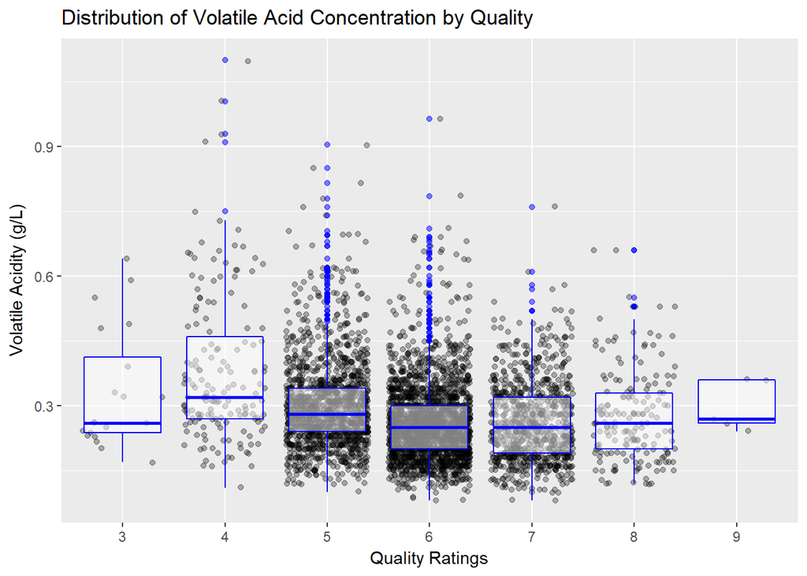

```
##
##  Pearson's product-moment correlation
##
## data:  as.numeric(quality) and volatile.acidity
## t = -13.891, df = 4896, p-value < 2.2e-16
## alternative hypothesis: true correlation is not equal to 0
## 95 percent confidence interval:
##  -0.2215214 -0.1676307
## sample estimates:
##       cor
## -0.194723
```

- Quality looks to increase with decreasing volatile acid concentration. There seems to be a number of outliers in the distribution of quality ratings 5 and 6, which is reflective of the higher count amounts for those categories.

### Plot Two

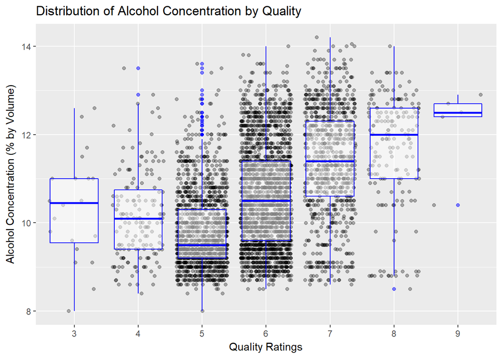

```
##
##  Pearson's product-moment correlation
##
## data:  as.numeric(quality) and alcohol
## t = 33.858, df = 4896, p-value < 2.2e-16
## alternative hypothesis: true correlation is not equal to 0
## 95 percent confidence interval:
##  0.4126015 0.4579941
## sample estimates:
##       cor
## 0.4355747
```

- Quality tends to increase with increasing alcohol concentration. Although the median alcohol concentration increases from quality rating of 5 to 4 and 3.

### Plot Three

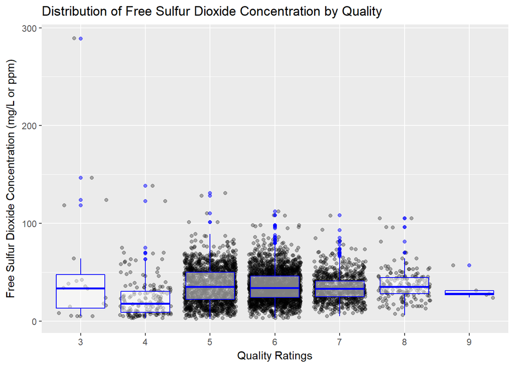

```
## [1] "Full Dataset"
```

```
##
##  Pearson's product-moment correlation
##
## data:  as.numeric(quality) and free.sulfur.dioxide
## t = 0.57085, df = 4896, p-value = 0.5681
## alternative hypothesis: true correlation is not equal to 0
## 95 percent confidence interval:
##  -0.01985292  0.03615626
## sample estimates:
##         cor
## 0.008158067
```

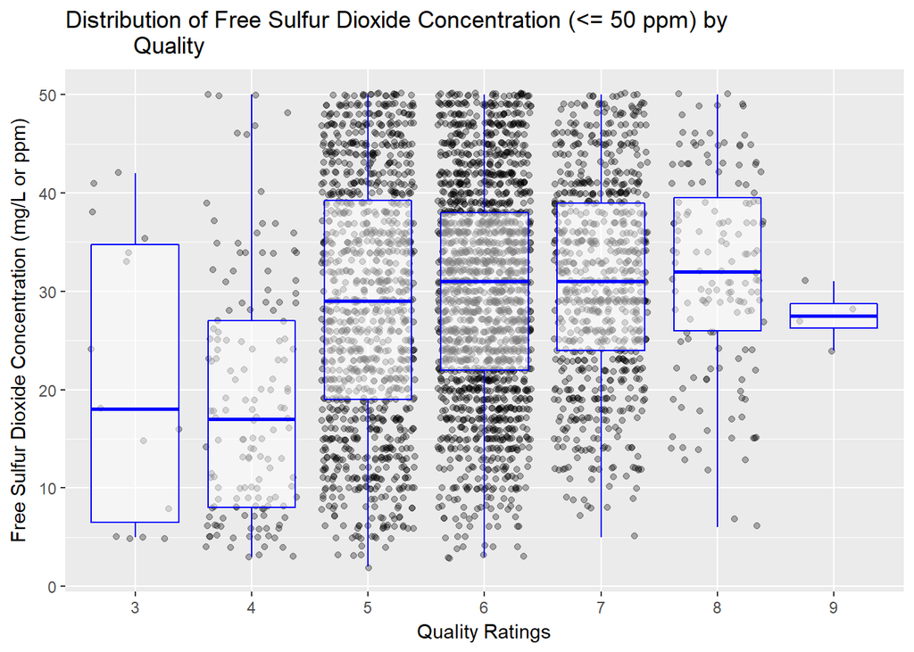

```
## [1] "Subset with free.sulfur.dioxide <= 50"
```

```
##
##  Pearson's product-moment correlation
##
## data:  as.numeric(quality) and free.sulfur.dioxide
## t = 10.337, df = 4028, p-value < 2.2e-16
## alternative hypothesis: true correlation is not equal to 0
## 95 percent confidence interval:
##  0.1305243 0.1906818
## sample estimates:
##       cor
## 0.1607524
```

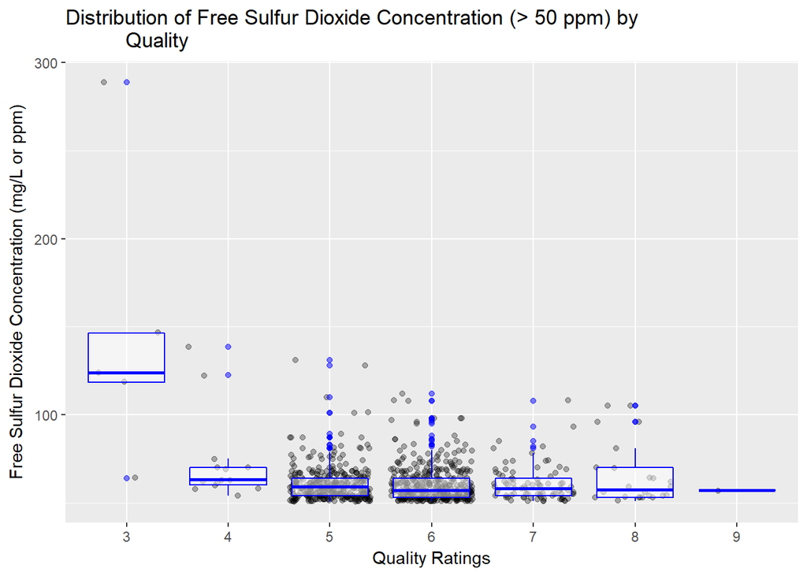

```
## [1] "Subset with free.sulfur.dioxide > 50"
```

```
##
##  Pearson's product-moment correlation
##
## data:  as.numeric(quality) and free.sulfur.dioxide
## t = -3.812, df = 866, p-value = 0.0001476
## alternative hypothesis: true correlation is not equal to 0
## 95 percent confidence interval:
##  -0.19335188 -0.06245395
## sample estimates:
##        cor
## -0.1284624
```

- Distribution of free sulfur dioxide concentrations for wine samples seems to show very little difference across quality ratings by looking at median value.
- Subsetting for free sulfur dioxide concentrations above and below 50 ppm shows an inflection point. Quality ratings increase with increasing free sulfur dioxide concentrations in the subset with concentrations less than 51 ppm, while quality ratings decreased with increasing free sulfur dioxide concentrations in the subset with concentrations above 50 ppm.

# Reflection

- I began my analysis by looking at features individually or as a cluster to see if they convey similar information (ie. acidity). I then proceeded to look more deeply at features I thought were more easily perceptible to a drinker to see if they correlated with quality.
- Looking at particular definitions of the features, volatile acidity and free sulfur dioxide stood out as being important to the sense of smell. Since smell contributes significantly to our perception of taste (or quality in this case), I dived deeper to see if they correlated significantly with quality of the wine. This inference ended up being true in regards to free sulfur dioxide concentration and volatile acid concentrations.
- Looking more deeply at the density feature, which I initially thought wasn’t going to be useful as a feature because of the very narrow range of values, pointed to a significant negative correlation with quality. This led me to the alcohol by volume feature because of it’s strong negative correlation with density. Alcohol ended up showing a signifant positive correlation with quality and was the largest factor in determining the percent variance (R^2) for quality.
- It was difficult to make a linear model to determine quality with the given features. All of the features looked to have a mostly non-linear correlation with quality. It would likely be more useful to use a machine learning algorithm to predict quality from the given features.
- Also, there was far more examples of wines with a quality ratings of 5, 6, and 7 when an even distribution count for all ratings may have helped to discern more prominent features of wines with qualities of 3, 4, 8, and 9 for a better model for quality predictions. This property of the data also made using a facet wrap to compare distributions ineffective.